# EJERCICIOS DEL BONO (An Introduction to Statistical Learning with Applications in R)

Armando Lara , Jorge Arguello,Dario Quishpe

2024-03-01

# Capitulo 5 - Ejercicio 2

Ahora la probabilidad de que una observación dada sea parte de una muestra bootstrap. Supongamos que obtenemos una muestra bootstrap a partir de un conjunto de n observaciones.

**a.** ¿Cuál es la probabilidad de que la primera observación bootstrap **no** sea la $j$-ésima observación de la muestra original? Justifica tu respuesta.

Esto es $1$ menos la probabilidad de que sea la $j$-ésima, es decir, $1 - \frac{1}{n}$.

**b**. ¿Cuál es la probabilidad de que la segunda observación bootstrap **no** sea la $j$-ésima observación de la muestra original?

Dado que cada observación bootstrap es una muestra aleatoria, esta probabilidad es la misma, $1 - \frac{1}{n}$.

**c.** Argumenta que la probabilidad de que la $j$-ésima observación **no** esté en la muestra bootstrap es $(1 - \frac{1}{n})^n$.

Para que la $j$-ésima observación no esté en la muestra, no debería ser elegida para cada una de las $n$ posiciones, es decir, no seleccionada para $1, 2, ..., n$. Por lo tanto, la probabilidad es $(1 - \frac{1}{n})^n$.

**d.** Cuando $n = 5$, ¿cuál es la probabilidad de que la $j$-ésima observación esté en la muestra bootstrap?

```r
n <- 5
1 - (1 - 1 / n)^n
```

```
## [1] 0.67232
```

**e**. Cuando $n = 100$, ¿cuál es la probabilidad de que la $j$-ésima observación esté en la muestra bootstrap?

```r
n <- 100
1 - (1 - 1 / n)^n
```

```
## [1] 0.6339677
```

```r
n <- 100000
1 - (1 - 1 / n)^n
```

```
## [1] 0.6321224
```

**g.** Crea un gráfico que muestre, para cada valor entero de $n$ de 1 a 100,000, la probabilidad de que la $j$-ésima observación esté en la muestra bootstrap. Comenta sobre lo que observas.

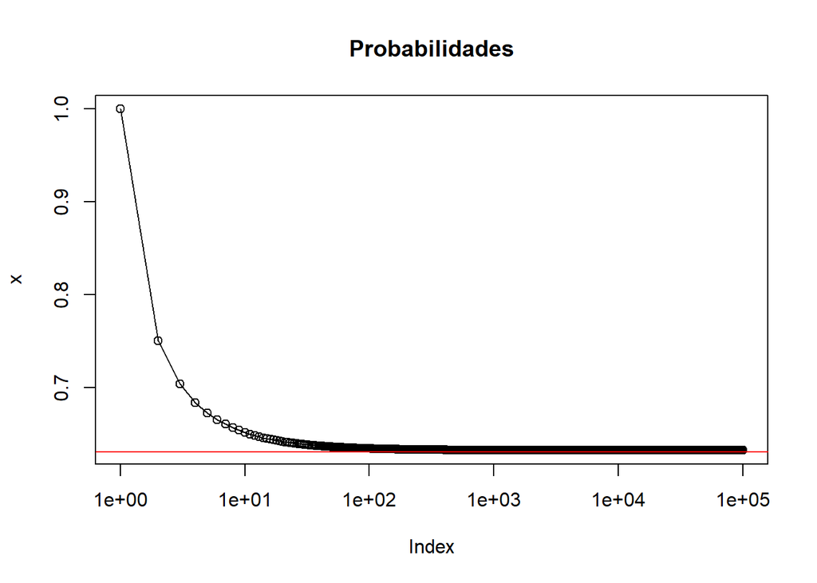

```r
x <- sapply(1:100000, function(n) 1 - (1 - 1 / n)^n)
plot(x, log = "x", type = "o",main="Probabilidades")
abline(h=0.63,col="red")
```

La probabilidad se aproxima rápidamente a 0.63 con el aumento de $n$.

Nota que
$$e^x = \lim_{{x \to \infty}} \left(1 + \frac{x}{n}\right)^n,$$
entonces con $x = -1$, podemos ver que nuestro límite es $1 - e^{-1} = 1 - \frac{1}{e}$.

**h.** Investigaremos numéricamente la probabilidad de que una muestra bootstrap de tamaño $n = 100$ contenga la $j$-ésima observación. Aquí $j = 4$. Creamos repetidamente muestras bootstrap y cada vez registramos si la cuarta observación está contenida en la muestra bootstrap.

```r
store <- rep(NA, 10000)
for (i in 1:10000) {
  store[i] <- sum(sample(1:100, replace = TRUE) == 4) > 0
}
mean(store)
```

```
## [1] 0.6349
```

Comenta sobre los resultados obtenidos.

```r
store <- replicate(10000, sum(sample(1:100, replace = TRUE) == 4) > 0)
mean(store)
```

```
## [1] 0.6306
```

La probabilidad de incluir el $4$ al remuestrear números del $1$ al $100$ se acerca a $1 - \left(1 - \frac{1}{100}\right)^{100}$.

# Capitulo 5 - Ejercicio 2

En el Capítulo 4, utilizamos regresión logística para predecir la probabilidad de `default` utilizando `income` y `balance` en el conjunto de datos `Default`. Ahora estimaremos el error de prueba de este modelo de regresión logística utilizando el enfoque de conjunto de validación. No olvides establecer una semilla aleatoria antes de comenzar tu análisis.

**a.** Ajusta un modelo de regresión logística que utilice `income` y `balance` para predecir `default`.

```r
#install.packages("ISLR2")
library(ISLR2)
set.seed(42)
modelo <- glm(default ~ income + balance, data = Default, family = "binomial")
summary(modelo)
```

```
##
## Call:
## glm(formula = default ~ income + balance, family = "binomial",
##     data = Default)
##
## Coefficients:
##               Estimate Std. Error z value Pr(>|z|)
## (Intercept) -1.154e+01  4.348e-01 -26.545  < 2e-16 ***
## income       2.081e-05  4.985e-06   4.174 2.99e-05 ***
## balance      5.647e-03  2.274e-04  24.836  < 2e-16 ***
## ---
## Signif. codes:  0 '***' 0.001 '**' 0.01 '*' 0.05 '.' 0.1 ' ' 1
##
## (Dispersion parameter for binomial family taken to be 1)
##
##     Null deviance: 2920.6  on 9999  degrees of freedom
## Residual deviance: 1579.0  on 9997  degrees of freedom
## AIC: 1585
##
## Number of Fisher Scoring iterations: 8
```

**b.** Utilizando el enfoque de conjunto de validación, estima el error de prueba de este modelo. Para hacer esto, debes realizar los siguientes pasos: i. Divide el conjunto de muestras en un conjunto de entrenamiento y un conjunto de validación. ii. Ajusta un modelo de regresión logística múltiple utilizando solo las observaciones de entrenamiento. iii. Obtiene una predicción del estado de `default` para cada individuo en el conjunto de validación calculando la probabilidad posterior de `default` para ese individuo y clasificando al individuo en la categoría `default` si la probabilidad posterior es mayor que 0.5. iv. Calcula el error del conjunto de validación, que es la fracción de observaciones en el conjunto de validación que están mal clasificadas.

```r
train <- sample(nrow(Default), nrow(Default) / 2)
modelo <- glm(default ~ income + balance, data = Default, family = "binomial", subset = train)
prediccion <- ifelse(predict(modelo, newdata = Default[-train, ], type = "response") > 0.5, "SI", "No")
table(prediccion, Default$default[-train])
```

```
##
## prediccion   No  Yes
##         No 4817  110
##         SI   20   53
```

```r
mean(prediccion != Default$default[-train])
```

[output not shown]

**c.** Repite el proceso en (b) tres veces, utilizando tres divisiones diferentes de las observaciones en un conjunto de entrenamiento y un conjunto de validación. Comenta sobre los resultados obtenidos.

```r
replicate(3, {
  train <- sample(nrow(Default), nrow(Default) / 2)
  modelo <- glm(default ~ income + balance, data = Default, family = "binomial", subset = train)
  prediccion <- ifelse(predict(modelo, newdata = Default[-train, ], type = "response") > 0.5, "SI", "No")
  mean(prediccion != Default$default[-train])
})
```

```
## [1] 0.0368 0.0396 0.0366
```

Los resultados obtenidos son variables y dependen de las muestras asignadas a entrenamiento vs prueba(similar a Training test).

**d.** Ahora considera un modelo de regresión logística que predice la probabilidad de `default` utilizando `income`, `balance`, y una variable ficticia para `student`. Estima el error de prueba para este modelo utilizando el enfoque de conjunto de validación. Comenta si incluir una variable ficticia para `student` conduce o no a una reducción en la tasa de error de prueba.

```r
replicate(3, {
  train <- sample(nrow(Default), nrow(Default) / 2)
  modelo <- glm(default ~ income + balance + student, data = Default, family = "binomial", subset = train)
  predichos <- ifelse(predict(modelo, newdata = Default[-train, ], type = "response") > 0.5, "SI", "No")
  mean(predichos != Default$default[-train])
})
```

```
## [1] 0.0380 0.0340 0.0358
```

Incluir `student` no parece mejorar sustancialmente el error de prueba.

# Capitulo 5 - Ejercicio 2

Continuamos considerando el uso de un modelo de regresión logística para predecir la probabilidad de `default` utilizando `income` y `balance` en el conjunto de datos `Default`. En particular, ahora calcularemos estimaciones para los errores estándar de los coeficientes de regresión logística para `income` y `balance` de dos maneras diferentes: (1) usando el bootstrap y (2) usando la fórmula estándar para calcular los errores estándar en la función `glm()`. No olvides establecer una semilla aleatoria antes de comenzar tu análisis.

**a.** Utilizando las funciones `summary()` y `glm()`, determina los errores estándar estimados para los coeficientes asociados con `income` y `balance` en un modelo de regresión logística múltiple que utiliza ambos predictores.

```r
set.seed(1)
modelo <- glm(default ~ income + balance, data = Default, family = "binomial")
summary(modelo)
```

```
##
## Call:
## glm(formula = default ~ income + balance, family = "binomial",
##     data = Default)
##
## Coefficients:
##               Estimate Std. Error z value Pr(>|z|)
## (Intercept) -1.154e+01  4.348e-01 -26.545  < 2e-16 ***
## income       2.081e-05  4.985e-06   4.174 2.99e-05 ***
## balance      5.647e-03  2.274e-04  24.836  < 2e-16 ***
## ---
## Signif. codes:  0 '***' 0.001 '**' 0.01 '*' 0.05 '.' 0.1 ' ' 1
##
## (Dispersion parameter for binomial family taken to be 1)
##
##     Null deviance: 2920.6  on 9999  degrees of freedom
## Residual deviance: 1579.0  on 9997  degrees of freedom
## AIC: 1585
##
## Number of Fisher Scoring iterations: 8
```

**b.** Escribe una función, `boot.fn()`, que tome como entrada el conjunto de datos `Default` así como un índice de las observaciones, y que devuelva las estimaciones de coeficientes para `income` y `balance` en el modelo de regresión logística múltiple.

```r
boot.fn <- function(x, i) {
  modelo <- glm(default ~ income + balance, data = x[i, ], family = "binomial")
  coef(modelo)[-1]
}
```

**c.** Usa la función `boot()` junto con tu función `boot.fn()` para estimar los errores estándar de los coeficientes de regresión logística para `income` y `balance`.

```r
library(boot)
set.seed(1)
#boot(Default,boot.fn,R=10)
boot::boot(Default,boot.fn,R=10)
```

```
##
## ORDINARY NONPARAMETRIC BOOTSTRAP
##
##
## Call:
## boot::boot(data = Default, statistic = boot.fn, R = 10)
##
##
## Bootstrap Statistics :
##         original       bias     std. error
## t1* 2.080898e-05 1.589838e-06 3.324258e-06
## t2* 5.647103e-03 1.784084e-05 1.752440e-04
```

**d.** Comenta sobre los errores estándar estimados obtenidos utilizando la función `glm()` y tu función de bootstrap.